# Problem Set 6

Prof. Bisbee

Due Date: 2022/10/23 @ 11:59PM CST

## Getting Set Up

If you haven’t already, create a folder for this course, and then a subfolder within for the second lecture `Topic8_Regression`, and two additional subfolders within `code` and `data`.

Open `RStudio` and create a new RMarkDown file (`.Rmd`) by going to `File -> New File -> R Markdown...`. Change the title to `"DS1000: Problem Set 6"` and the author to your full name. Save this file as `[LAST NAME]_ps6.Rmd` to your `code` folder.

If you haven’t already, download the `mv.Rds` file from the course [github page](https://github.com/jbisbee1/DS1000-F2022/blob/master/Lectures/Topic8_Regression/data/mv.Rds) and save it to your `data` folder.

The contents of this problem set can be found in the following resources:

- [Topic 6](https://github.com/jbisbee1/DS1000-F2022/tree/master/Lectures/Topic6_UnivariateVisualization) parts 1 & 2 (univariate visualization)
- [Topic 7](https://github.com/jbisbee1/DS1000-F2022/tree/master/Lectures/Topic7_ConditionalVariation) parts 1 & 2 (conditional analysis)
- [Topic 8](https://github.com/jbisbee1/DS1000-F2022/tree/master/Lectures/Topic8_Regression) parts 1 & 2 (regression, RMSE, and cross validation)

Require `tidyverse` and load the `mv.Rds` data to `mv`.

```r
# INSERT CODE HERE
require(tidyverse)
mv<-read_rds("../data/mv.rds")
```

**NOTE**: Starting with this problem set, we are moving to a system with fewer questions that are each more involved. For EACH of the questions below, you are expected to:

1. Perform univariate analysis on each of the two variables separately (determine their class, identifying missingness, and plot with the appropriate figure).
2. Plot the conditional relationship between the two variables using the appropriate figure. Transform the variables if needed by logging highly skewed data.
3. Estimate the linear regression model.
4. Evaluate model fit with 1) visual analysis of the residuals and 2) cross validation.

## Question 1 [10 points]

- **Research Question:** Are longer movies more expensive to make?
- **Theory:** Longer running movies take more time to make. Time is money.
- **Hypothesis:** The longer the movie, the more expensive it is.
- *Hints:* You are looking at the conditional relationship between `budget` and `runtime`.

```r
# INSERT CODE HERE
mv %>%
count(is.na(budget))
```

```
## # A tibble: 2 × 2
##   `is.na(budget)`     n
##   <lgl>           <int>
## 1 FALSE            3191
## 2 TRUE             4482
```

```r
mv %>%
count(is.na(runtime))
```

```
## # A tibble: 2 × 2
##   `is.na(runtime)`     n
##   <lgl>            <int>
## 1 FALSE             7669
## 2 TRUE                 4
```

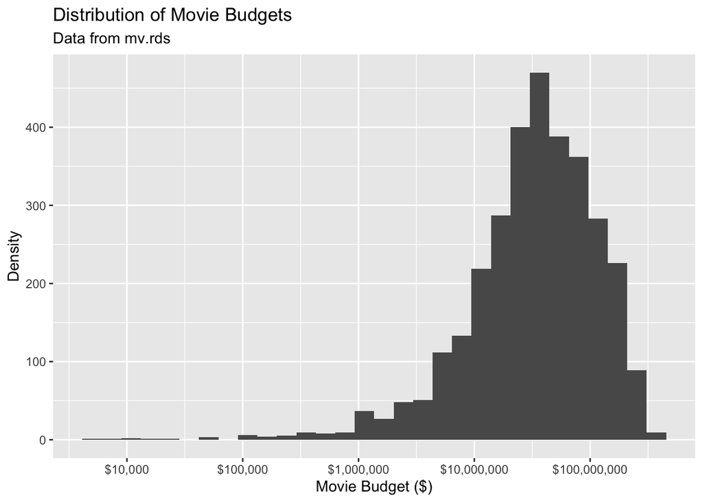

```r
mv %>%
ggplot(aes(x=budget))+
geom_histogram()+
scale_x_log10(label = scales::dollar)+
labs(title = 'Distribution of Movie Budgets',
     subtitle = 'Data from mv.rds',
x='Movie Budget ($)',
y='Density')
```

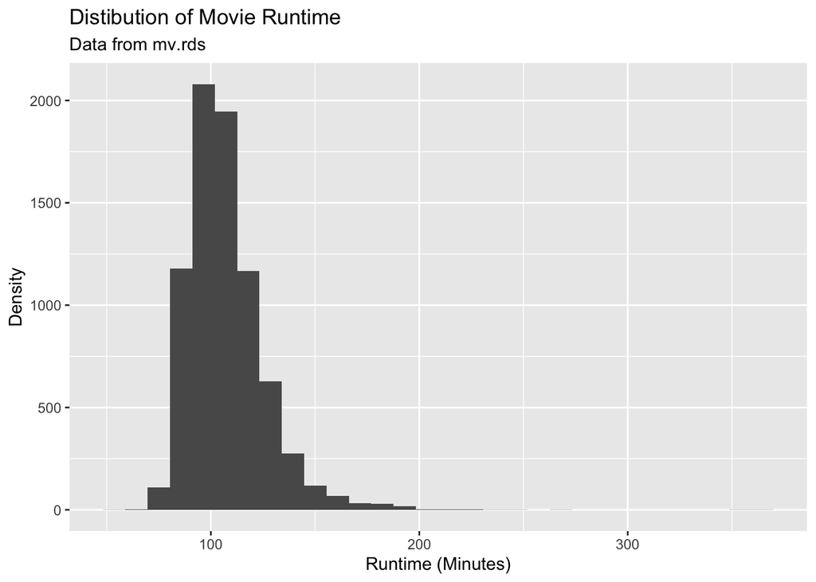

```r
mv %>%
ggplot(aes(x=runtime))+
geom_histogram()+
labs(title = 'Distibution of Movie Runtime',
     subtitle = 'Data from mv.rds',
x='Runtime (Minutes)',
y='Density')
```

```r
mv %>%
group_by(runtime)%>%
summarise(meanBudget = mean(budget, na.rm=T))
```

```
## # A tibble: 139 × 2
##    runtime meanBudget
##      <dbl>      <dbl>
##  1      55       NaN
##  2      63  35709321.
##  3      69       NaN
##  4      71       NaN
##  5      72  29435266.
##  6      73       NaN
##  7      74     99207.
##  8      75  26757191.
##  9      76  51759120.
## 10      77  40883393.
## # … with 129 more rows
```

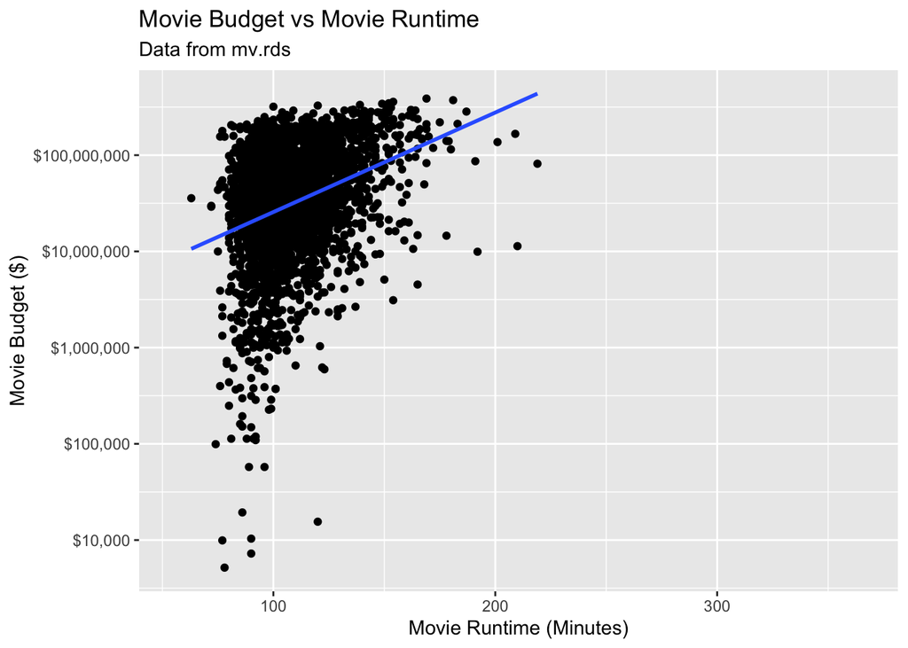

```r
mv %>%
ggplot(aes(x=runtime, y=budget))+
scale_y_log10(label=scales::dollar)+
geom_point()+
geom_smooth(method ='lm', se = F)+
labs(title = 'Movie Budget vs Movie Runtime',
     subtitle = 'Data from mv.rds',
x='Movie Runtime (Minutes)',
y='Movie Budget ($)')
```

```r
mv <- mv%>%
drop_na(budget)%>%
drop_na(runtime)%>%
mutate(logBudget = log(budget))

m <- lm(logBudget ~ runtime,data = mv)
m
```

```
##
## Call:
## lm(formula = logBudget ~ runtime, data = mv)
##
## Coefficients:
## (Intercept)      runtime
##    14.67890      0.02381
```

```r
mv$predictionsQ1 <- predict(m)
mv$errorsQ1 <- mv$logBudget - mv$predictionsQ1
summary(mv$errorsQ1)
```

```
##    Min. 1st Qu.  Median    Mean 3rd Qu.    Max.
## -7.9851 -0.6238  0.1382  0.0000  0.8538  2.5343
```

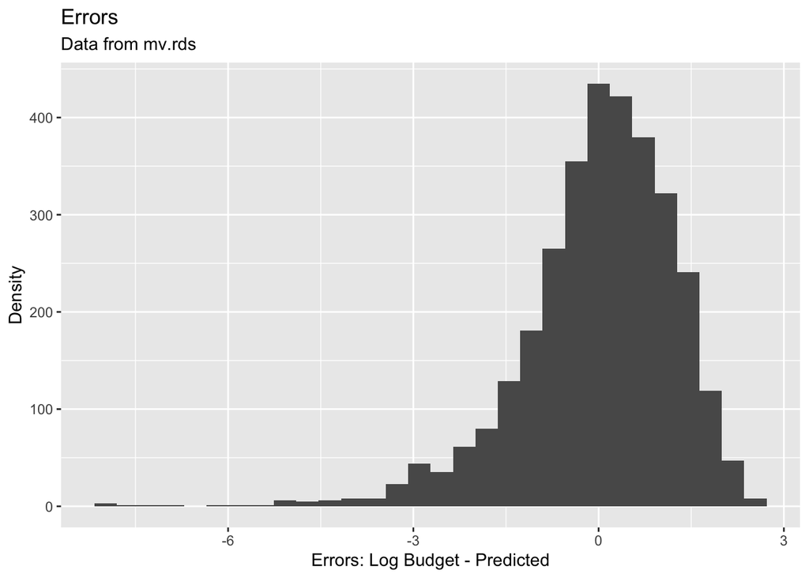

```r
se <- mv$errorsQ1^2
mse <- mean(se, na.rm=T)
rmse <- sqrt(mse)

mv %>%
ggplot(aes(x = errorsQ1)) +
geom_histogram() +
labs(title = 'Errors',
     subtitle = 'Data from mv.rds',
     x = 'Errors: Log Budget - Predicted',
     y = 'Density')
```

```r
bsRes <- NULL
for(i in 1:100) {
  inds <- sample(1:nrow(mv),size = 1000,replace = F)
  train <- mv %>% slice(inds)
  test <- mv %>% slice(-inds)
  mTrain <- lm(logBudget ~ runtime,train)

  bsRes <- test %>%
  mutate(preds = predict(mTrain,newdata = test)) %>%
  summarise(rmseQ1 = sqrt(mean((logBudget - preds)^2,na.rm=T))) %>%
  bind_rows(bsRes)
}

bsRes %>%
summarise_all(mean,na.rm=T)
```

```
## # A tibble: 1 × 1
##   rmseQ1
##    <dbl>
## 1   1.24
```

## Question 2 [10 points]

- **Research Question:** Are movies getting worse?
- **Theory:** Changes in the economy have resulted in Hollywood taking fewer and fewer artistic risks, prioritizing cinematic universes like Marvel and reducing the overall quality of movies.
- **Hypothesis:** The more recent the movie, the worse it is.
- *Hints:* You are looking at the conditional relationship between `score` and `year`.

```r
# INSERT CODE HERE
mv %>%
glimpse()
```

```
## Rows: 3,189
## Columns: 23
## $ title         <chr> "Almost Famous", "American Psycho", "Gladiator", "Requie…
## $ rating        <chr> "R", "R", "R", "Unrated", "R", "PG-13", "R", "PG-13", "P…
## $ genre         <chr> "Adventure", "Comedy", "Action", "Drama", "Mystery", "Ad…
## $ year          <dbl> 2000, 2000, 2000, 2000, 2000, 2000, 2000, 2000, 2000, 20…
## $ released      <chr> "September 22, 2000 (United States)", "April 14, 2000 (U…
## $ score         <dbl> 7.9, 7.6, 8.5, 8.3, 8.4, 7.8, 6.2, 6.4, 5.7, 7.4, 6.4, 7…
## $ votes         <dbl> 260000, 514000, 1400000, 786000, 1200000, 542000, 238000…
## $ director      <chr> "Cameron Crowe", "Mary Harron", "Ridley Scott", "Darren …
## $ writer        <chr> "Cameron Crowe", "Bret Easton Ellis", "David Franzoni", …
## $ star          <chr> "Billy Crudup", "Christian Bale", "Russell Crowe", "Elle…
## $ country       <chr> "United States", "United States", "United States", "Unit…
## $ budget        <dbl> 93289619, 10883789, 160147179, 6996721, 13993443, 139934…
## $ gross         <dbl> 73677478, 53278578, 723586629, 11490339, 62266278, 66800…
## $ company       <chr> "Columbia Pictures", "Am Psycho Productions", "Dreamwork…
## $ runtime       <dbl> 122, 101, 155, 102, 113, 143, 88, 130, 100, 104, 130, 16…
## $ id            <dbl> 877, 64, 1163, 2050, 52, 3795, 5544, 9301, 1093, 101, 68…
## $ imdb_id       <chr> "0181875", "0144084", "0172495", "0180093", "0209144", "…
## $ bechdel_score <dbl> 3, 3, 0, 3, 1, 2, 3, 2, 3, 1, 2, 3, 3, 0, NA, NA, 1, NA,…
## $ boxoffice_a   <dbl> 50586063, 23431686, 291849463, 5652546, 39717849, 363257…
## $ language      <chr> "English, French", "English, Spanish, Cantonese", "Engli…
## $ logBudget     <dbl> 18.35122, 16.20278, 18.89160, 15.76095, 16.45410, 18.756…
## $ predictionsQ1 <dbl> 17.58367, 17.08367, 18.36939, 17.10748, 17.36939, 18.083…
## $ errorsQ1      <dbl> 0.76754778, -0.88088505, 0.52221543, -1.34652740, -0.915…
```

```r
mv %>%
count(is.na(year))
```

```
## # A tibble: 1 × 2
##   `is.na(year)`     n
##   <lgl>         <int>
## 1 FALSE          3189
```

```r
mv %>%
count(is.na(score))
```

```
## # A tibble: 2 × 2
##   `is.na(score)`     n
##   <lgl>          <int>
## 1 FALSE           3186
## 2 TRUE               3
```

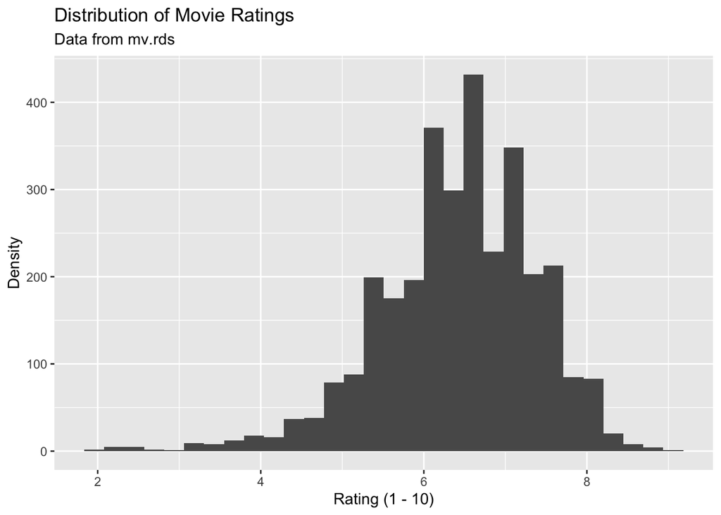

```r
mv %>%
ggplot(aes(x=score))+
geom_histogram()+
labs(title = 'Distribution of Movie Ratings',
     subtitle = 'Data from mv.rds',
     x='Rating (1 - 10)',
     y='Density')
```

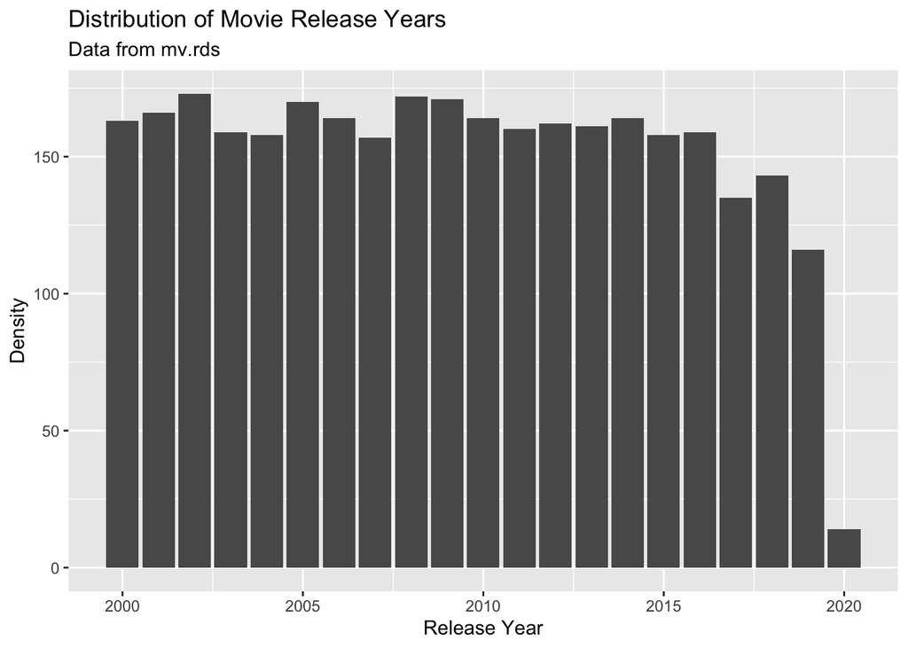

```r
mv %>%
ggplot(aes(x=year))+
geom_bar()+
labs(title = 'Distribution of Movie Release Years',
     subtitle = 'Data from mv.rds',
     x='Release Year',
     y='Density')
```